### Kelp forest fish - effective number of species

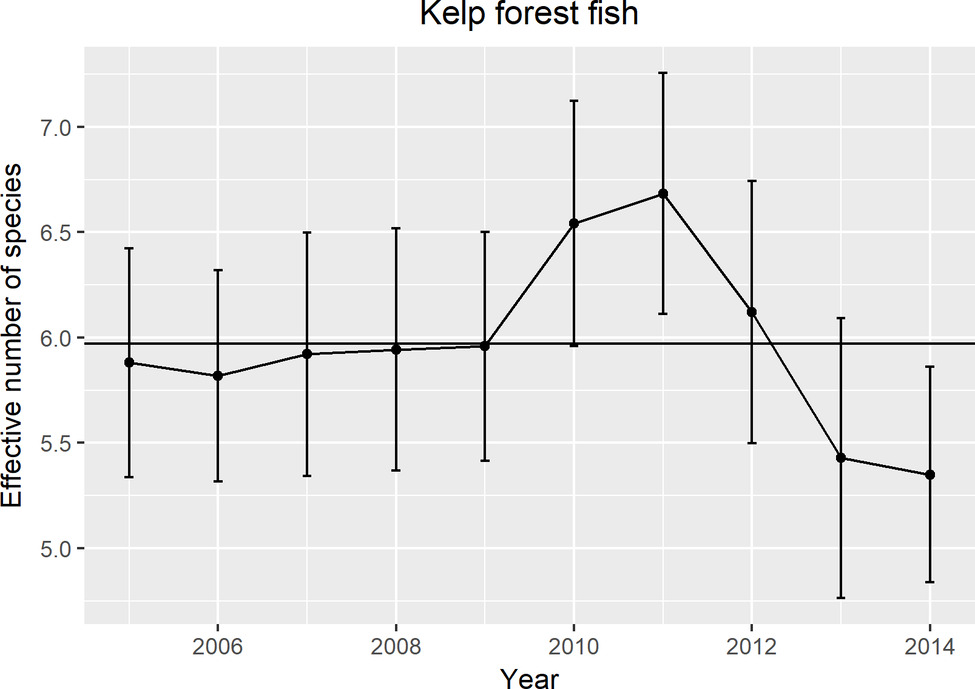

**Click for Details**

Mean annual effective number of species for three taxonomic groups: kelp forest fishes (top), mobile demersal invertebrates (middle), and deeper water fishes (bottom). Shannon-Weiner diversity was converted to effective numbers of species, which allows for a more direct and intuitive comparison of community diversity over time. Kelp forest fish were surveyed across 86 shallow reef sites (3 to 16 meters depth) around the four northern Channel Islands from 2005 to 2014. Mobile invertebrates were surveyed across 63 shallow reef sites (3 to 16 meters depth) around the four northern Channel Islands from 1982 to 2016. Deep-water fish were surveyed at three reefs off the Channel Islands (Piggy Bank, Footprint, and Anacapa passage) at depths ranging from 40 to 407 meters in 1995 and annually between 1998 and 2011. Error bars indicate the 95 percent confidence interval in a given year. The horizontal line is the mean across sites over time. Data source: Amalgamated dataset of [SBC LTER](https://sbclter.msi.ucsb.edu/), [CINP Kelp Forest Monitoring Program](https://www.nps.gov/im/medn/kelp-forest-communities.htm), and [PISCO](http://www.piscoweb.org/); Figure: [SBC MBON](http://sbc.marinebon.org/)

### Bottom mobile invertebrates - effective number of species

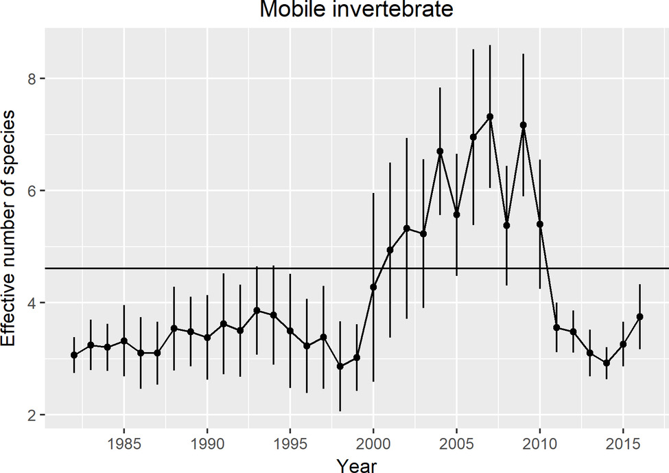

**Click for Details**

Mean annual effective number of species for three taxonomic groups: kelp forest fishes (top), mobile demersal invertebrates (middle), and deeper water fishes (bottom). Shannon-Weiner diversity was converted to effective numbers of species, which allows for a more direct and intuitive comparison of community diversity over time. Kelp forest fish were surveyed across 86 shallow reef sites (3 to 16 meters depth) around the four northern Channel Islands from 2005 to 2014. Mobile invertebrates were surveyed across 63 shallow reef sites (3 to 16 meters depth) around the four northern Channel Islands from 1982 to 2016. Deep-water fish were surveyed at three reefs off the Channel Islands (Piggy Bank, Footprint, and Anacapa passage) at depths ranging from 40 to 407 meters in 1995 and annually between 1998 and 2011. Error bars indicate the 95 percent confidence interval in a given year. The horizontal line is the mean across sites over time. Data source: Amalgamated dataset of [SBC LTER](https://sbclter.msi.ucsb.edu/), [CINP Kelp Forest Monitoring Program](https://www.nps.gov/im/medn/kelp-forest-communities.htm), and [PISCO](http://www.piscoweb.org/); Figure: [SBC MBON](http://sbc.marinebon.org/)

### Deeper water fish - effective number of species

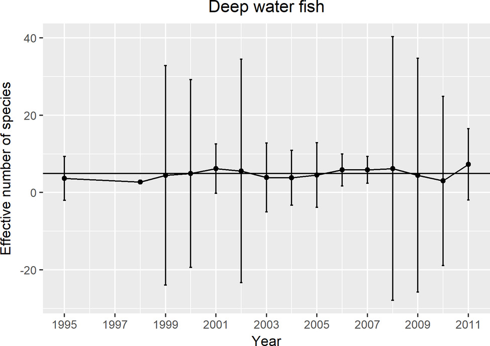

**Click for Details**

Mean annual effective number of species for three taxonomic groups: kelp forest fishes (top), mobile demersal invertebrates (middle), and deeper water fishes (bottom). Shannon-Weiner diversity was converted to effective numbers of species, which allows for a more direct and intuitive comparison of community diversity over time. Kelp forest fish were surveyed across 86 shallow reef sites (3 to 16 meters depth) around the four northern Channel Islands from 2005 to 2014. Mobile invertebrates were surveyed across 63 shallow reef sites (3 to 16 meters depth) around the four northern Channel Islands from 1982 to 2016. Deep-water fish were surveyed at three reefs off the Channel Islands (Piggy Bank, Footprint, and Anacapa passage) at depths ranging from 40 to 407 meters in 1995 and annually between 1998 and 2011. Error bars indicate the 95 percent confidence interval in a given year. The horizontal line is the mean across sites over time. Data source: Amalgamated dataset of [SBC LTER](https://sbclter.msi.ucsb.edu/), [CINP Kelp Forest Monitoring Program](https://www.nps.gov/im/medn/kelp-forest-communities.htm), and [PISCO](http://www.piscoweb.org/); Figure: [SBC MBON](http://sbc.marinebon.org/)

### Kelp forest fish - thermal affinity ratio

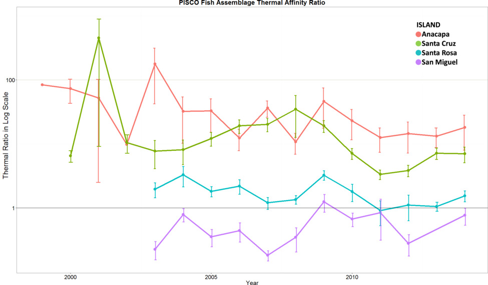

**Figure App.F.15.2.**. A figure showing the temperature preferences for kelp-forest fish species across the four Northern Channel Islands. Anacapa and Santa Cruz Islands show a more southern (warmer) collection of fish species while Santa Rosa and San Miguel Islands have a more northern (cooler) collection of fish species.

**Click for Details**

The thermal ratio of the kelp forest fish assemblage shows the relative proportion of the fish community that have a southern (warmer) vs. northern (cooler) affiliation. Islands to the east, Anacapa (orange) and Santa Cruz (green), have a higher ratio of warm:cool species than Santa Rosa (blue) and San Miguel (purple), which are to the west. Santa Cruz Island is highly variable possibly because it is in a transition zone in the thermal gradient around the islands, which may make the fish community at this island more susceptible to the influence of climate changes. Note the log scale for the Y-axis.Data source: [CINP Kelp Forest Monitoring Program](https://www.nps.gov/im/medn/kelp-forest-communities.htm), and [PISCO](http://www.piscoweb.org/); Figure: [R. Freedman/NOAA](https://channelislands.noaa.gov/contact/freedman.html)